# Lab 2: Cats vs Dogs

### Part (b) - 3pt

Train `large_net` with all default parameters, except set `learning_rate=0.1`. Does the model take longer/shorter to train? Plot the training curve. Describe the effect of *increasing* the learning rate.

```
Files already downloaded and verified
Files already downloaded and verified
Epoch 1: Train err: 0.4295, Train loss: 0.67437779712677 |Validation err: 0.3595, Validation loss: 0.6350857093930244
Epoch 2: Train err: 0.36075, Train loss: 0.6411805458068848 |Validation err: 0.3535, Validation loss: 0.6361209936439991
Epoch 3: Train err: 0.365125, Train loss: 0.6321813461780548 |Validation err: 0.3385, Validation loss: 0.6056603882461786
Epoch 4: Train err: 0.352625, Train loss: 0.6233456182479858 |Validation err: 0.3575, Validation loss: 0.6362800188362598
Epoch 5: Train err: 0.34075, Train loss: 0.6108013873100281 |Validation err: 0.3305, Validation loss: 0.6064918786287308
Epoch 6: Train err: 0.323375, Train loss: 0.5921835997104645 |Validation err: 0.317, Validation loss: 0.5967769594863057
Epoch 7: Train err: 0.3145, Train loss: 0.5817317583560944 |Validation err: 0.3365, Validation loss: 0.6204487886279821
Epoch 8: Train err: 0.29825, Train loss: 0.5660300073623658 |Validation err: 0.3285, Validation loss: 0.5983372200280428
Epoch 9: Train err: 0.290875, Train loss: 0.552809501171112 |Validation err: 0.3315, Validation loss: 0.6084455158561468
Epoch 10: Train err: 0.278625, Train loss: 0.539032607793808 |Validation err: 0.306, Validation loss: 0.5918631898239255
Epoch 11: Train err: 0.272375, Train loss: 0.5236025826931 |Validation err: 0.33, Validation loss: 0.6430060230195522
Epoch 12: Train err: 0.267375, Train loss: 0.5220149435997009 |Validation err: 0.2925, Validation loss: 0.6413561534136534
Epoch 13: Train err: 0.266, Train loss: 0.5160510110855102 |Validation err: 0.3125, Validation loss: 0.6349832843989134
Epoch 14: Train err: 0.24875, Train loss: 0.4951590054035187 |Validation err: 0.3145, Validation loss: 0.7193072671070695
Epoch 15: Train err: 0.264625, Train loss: 0.519231944322586 |Validation err: 0.314, Validation loss: 0.6381420725956559
Epoch 16: Train err: 0.252625, Train loss: 0.5020012385845184 |Validation err: 0.3225, Validation loss: 0.6551959458738565
Epoch 17: Train err: 0.23875, Train loss: 0.481714787364006 |Validation err: 0.357, Validation loss: 0.6440742611885071
Epoch 18: Train err: 0.23375, Train loss: 0.47645506453514097 |Validation err: 0.3375, Validation loss: 0.6777342790737748
Epoch 19: Train err: 0.218125, Train loss: 0.45134368968009947 |Validation err: 0.3445, Validation loss: 0.7232250478118658
Epoch 20: Train err: 0.217875, Train loss: 0.45516350817680357 |Validation err: 0.3245, Validation loss: 0.6354950983077288
Epoch 21: Train err: 0.23275, Train loss: 0.47897080445289614 |Validation err: 0.3255, Validation loss: 0.8348110988736153
Epoch 22: Train err: 0.234875, Train loss: 0.4808810565471649 |Validation err: 0.334, Validation loss: 0.7191346418112516
Epoch 23: Train err: 0.21575, Train loss: 0.4563647754192352 |Validation err: 0.316, Validation loss: 0.7083508176729083
Epoch 24: Train err: 0.2355, Train loss: 0.47718250966072084 |Validation err: 0.327, Validation loss: 0.7333047650754452
Epoch 25: Train err: 0.22025, Train loss: 0.4583414270877838 |Validation err: 0.3315, Validation loss: 0.7806987538933754
Epoch 26: Train err: 0.209625, Train loss: 0.4519626965522766 |Validation err: 0.3435, Validation loss: 0.7715998776257038
Epoch 27: Train err: 0.22175, Train loss: 0.4636160457134247 |Validation err: 0.3215, Validation loss: 0.7656293725594878
Epoch 28: Train err: 0.219375, Train loss: 0.46314777398109436 |Validation err: 0.348, Validation loss: 0.8202023077756166
Epoch 29: Train err: 0.235875, Train loss: 0.49053542733192446 |Validation err: 0.326, Validation loss: 0.8150460105389357
Epoch 30: Train err: 0.22, Train loss: 0.4623157248497009 |Validation err: 0.3165, Validation loss: 0.7585078496485949
Finished Training
Total time elapsed: 203.63 seconds
```

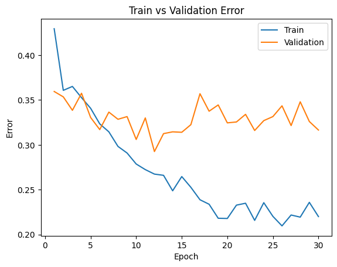

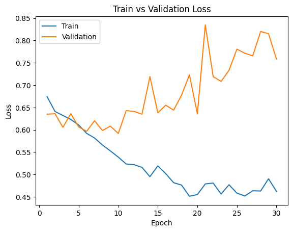

```python
train_net(large_net, learning_rate = 0.1)
model_path = get_model_name("large", batch_size = 64,
                            learning_rate= 0.1, epoch = 29)
plot_training_curve(model_path)

#Answer:

#The model took longer to train.
#Looking at the train curve, the model exhibits
#signs of overfitting at early stages in the training
#period. This is because the weights are modified
#too much at each epoch, so the model does not
#converge to its optimal accuracy, where validation
#data's loss is at its lowest. Increasing learning rate
#will let the model to lose accuracy.
```

### Part (c) - 3pt

Train `large_net` with all default parameters, including with `learning_rate=0.01`. Now, set `batch_size=512`. Does the model take longer/shorter to train? Plot the training curve. Describe the effect of *increasing* the batch size.

```
Files already downloaded and verified
Files already downloaded and verified
Epoch 1: Train err: 0.502625, Train loss: 0.694613516330719 |Validation err: 0.4935, Validation loss: 0.693454310297966
Epoch 2: Train err: 0.502, Train loss: 0.6934484839439392 |Validation err: 0.4805, Validation loss: 0.6927193701267242
Epoch 3: Train err: 0.477125, Train loss: 0.6924241930246353 |Validation err: 0.494, Validation loss: 0.6921168267726898
Epoch 4: Train err: 0.478875, Train loss: 0.6916632652282715 |Validation err: 0.474, Validation loss: 0.6915290355682373
Epoch 5: Train err: 0.468625, Train loss: 0.6904933676123619 |Validation err: 0.4575, Validation loss: 0.6904552429914474
Epoch 6: Train err: 0.458875, Train loss: 0.6896506026387215 |Validation err: 0.447, Validation loss: 0.689381331205368
Epoch 7: Train err: 0.45325, Train loss: 0.6885304935276508 |Validation err: 0.448, Validation loss: 0.6881940066814423
Epoch 8: Train err: 0.445625, Train loss: 0.6873400807380676 |Validation err: 0.443, Validation loss: 0.686993733048439
Epoch 9: Train err: 0.444125, Train loss: 0.686088215559721 |Validation err: 0.4355, Validation loss: 0.685817763209343
Epoch 10: Train err: 0.44125, Train loss: 0.6846113316714764 |Validation err: 0.436, Validation loss: 0.6839505881071091
Epoch 11: Train err: 0.439625, Train loss: 0.6832805164158344 |Validation err: 0.432, Validation loss: 0.6823321580886841
Epoch 12: Train err: 0.433, Train loss: 0.6815880872309208 |Validation err: 0.432, Validation loss: 0.680852398276329
Epoch 13: Train err: 0.42975, Train loss: 0.6799208149313927 |Validation err: 0.428, Validation loss: 0.6783946454524994
Epoch 14: Train err: 0.4225, Train loss: 0.6779238805174828 |Validation err: 0.421, Validation loss: 0.676338717341423
Epoch 15: Train err: 0.421125, Train loss: 0.6756023988127708 |Validation err: 0.4165, Validation loss: 0.6739865839481354
Epoch 16: Train err: 0.414125, Train loss: 0.673709973692894 |Validation err: 0.4055, Validation loss: 0.6708182692527771
Epoch 17: Train err: 0.410625, Train loss: 0.6712822429835796 |Validation err: 0.403, Validation loss: 0.66722771525383
Epoch 18: Train err: 0.4005, Train loss: 0.6677621155977249 |Validation err: 0.387, Validation loss: 0.665687158703804
Epoch 19: Train err: 0.399625, Train loss: 0.664214726537466 |Validation err: 0.3845, Validation loss: 0.6596384793519974
Epoch 20: Train err: 0.3875, Train loss: 0.6596253775060177 |Validation err: 0.3955, Validation loss: 0.655694454908371
Epoch 21: Train err: 0.38425, Train loss: 0.6550370417535305 |Validation err: 0.374, Validation loss: 0.649547815322876
Epoch 22: Train err: 0.379, Train loss: 0.6515219211578369 |Validation err: 0.374, Validation loss: 0.6449964195489883
Epoch 23: Train err: 0.36675, Train loss: 0.6469098553061485 |Validation err: 0.3685, Validation loss: 0.642036646604538
Epoch 24: Train err: 0.368625, Train loss: 0.6438647955656052 |Validation err: 0.3655, Validation loss: 0.6435673534870148
Epoch 25: Train err: 0.36525, Train loss: 0.6401287950575352 |Validation err: 0.3845, Validation loss: 0.6412773281335831
Epoch 26: Train err: 0.362, Train loss: 0.6385088674724102 |Validation err: 0.366, Validation loss: 0.6336372792720795
Epoch 27: Train err: 0.360375, Train loss: 0.6335447728633881 |Validation err: 0.3595, Validation loss: 0.6349429935216904
Epoch 28: Train err: 0.35775, Train loss: 0.631140697747469 |Validation err: 0.3645, Validation loss: 0.6296398341655731
Epoch 29: Train err: 0.353875, Train loss: 0.6242633946239948 |Validation err: 0.362, Validation loss: 0.6268091648817062
Epoch 30: Train err: 0.34525, Train loss: 0.6214020065963268 |Validation err: 0.3555, Validation loss: 0.6257748752832413
Finished Training
Total time elapsed: 141.96 seconds
```

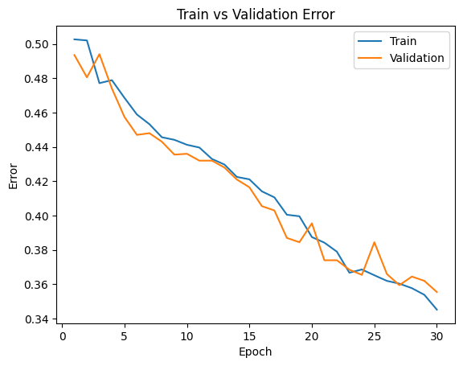

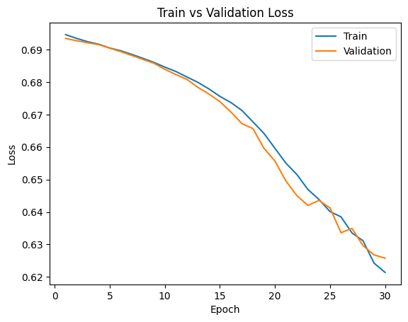

```python
large_net = LargeNet()
train_net(large_net, batch_size = 512)
model_path2 = get_model_name("large", batch_size = 512,
                             learning_rate = 0.01, epoch = 29)
plot_training_curve(model_path2)

#The model took less time to train because the
#batch size is large, and for each epoch,
#the data is broken into fewer groups, so it took
#less time to train. Compare to the default parameters,
#increasing batch size will make the model have higher
#errors and losses on both training and validation datasets.
#However, even though the large batch size causes the
#model to learn less, likely resulting in loss
#of accuracy in the end, there are no signs of overfitting
#after training.
```